# Lesson 11

Timothy Luna

9/15/2019

# 2C-L1 Fourier Transform

## Intro

Previously we’ve talked about images as functions, such as when using a Hough transform to extract information on edges using images as evidence.

Let’s wander back to the ideas of image processing and talk about frequency analysis.

Forty years ago or so all image processors would have been electrical engineers defining images in terms of frequency response. (Think Fourier analysis.) We (Computer Scientists), however, think about images in terms of data.

Thinking about frequency is important for *aliasing*

The goal of this lesson is to discuss aliasing from a frequency perspective.

## Dali

What do you see in this picture? Lots of high frquency info but when you step further away and blur your vision (enhancing low frequencies) it becomes a decent representaiton of Abraham Lincoln.

How does this tie into the idea of a *basis set*, representing bits of images?

[figure not shown]

## Basis Sets

**Basis set**: A basis [^1] **B** of a vector space **V** is a linearly independent subset of **V** that spans **V**.

Suppose that $B = {v_1,..,v_n}$ is a finite subset of a vector space **V** over a field **F** (such as **R** or **C**). then **B** is a basis if it satisfies the following properties:

- Linear independence: For all $a$ in **F** if $a_1 v_1 + ... + a_n v_n = 0$ then all $a_i = 0$. (Basically, there’s no way to combine the different bits to make zero, other than setting all coefficients to zero.)
- Spanning property: For every $x$ in $v$ it is possible to choose $a$ such that $x = a \cdot v = 0$.

Most students are used to basis sets being *orthogonal* but they don’t necessarily need to be orthogonal, they just need to be independent.

## Fourier

Having a basis set for images could be useful for analysis, especially for linear systems. We can examine all things independently and see how an operator applies to a whole image by doing it to a tiny bit.

To consider basis sets:

Consider an image as a point in an $N\times N$ space: this can be rasterized into a single vector $[x_{00}, x_{10}, x_{20}, ... ,x_{(n-1)(n-1)}]^T$

The ‘normal’ basis is just the vectors [000000…000100000…000]T

These are independent, can create any image, and NOT helpful as they’re single pixels.

Are there more useful bases?

What if we consider how quickly the image varies in different directions… (i.e., the gradient…)

[figure not shown]

This is the fourier decomposition:

Fourier: any periodic function can be rewritten as a weighted sum of sines and cosines at different frequencies. This is called the Fourier series! [^2]

## A Sum of Sines

The building block is a signal $A \sin (\omega x + \phi)$

How many degrees of freedom are there in a signal? Amplitude $(A)$ is a scale. $\omega$ and $\phi$ are frequency and phase. Which encodes coarse / fine? The frequency holds the ‘wiggliness’ and dictates how *fine* your signal will be.

## Time and Frequency

Here a signal $g(t)$ has two parts… $g(t) = \sin(2 \pi ft) + \frac{1}{3} \sin (2 \pi (3f) t)$

Linearity says the thing on the left looks like the two things on the right.

The *frequency decomposition* will have 1 measurement of power at $f$ and 1/3 measurement of power at 3f.

Remember that *any* signal can be made from sinusoids. If you really want a *square* wave then you keep adding finer and finer odd frequencies and eventually uou can show that a squre wave can be written as the infinite sum of frequencies.

$$A \sum \frac {1}{k} \sin 2\pi kt$$

We want to be able to look at a signal and compute with it to find the sinusoidal components.

To do a square wave you need an infinite sum of a decent amount of increasing frequencies. (finite in practice, don’t worry!)

What is phase, though? Right now it doesn’t matter! Our goal isn’t to reconstruct the image, we’re just curious how much power is in each frequency. If we were interested in reconstructing images we would care. We don’t right now.

## Fourier Transform

Since any signal can be represented by a sum of sinusoids, we can move from the notion of a continuous signal to a concept which allows us to know the ‘power’ of the frequencies. That can be done by the *Fourier transform*.

We want to understand the frequency $\omega$ so we reparameterize by $\omega$ instead of $x$. It takes a spacial signal in and spits out $A \sin (\omega x + \phi)$ information from -$\infty$ to $\infty$ for $\omega$.

For $\omega$ from $-\infty$ to $\infty$ $F(\omega)$ holds information on the amplitude and phase; how can it hold both? Using complex numbers!

$$F(\omega) = R(\omega) + i I(\omega)$$

$$A = \pm \sqrt{R(\omega)^2 + I(\omega)^2}$$
$$\phi = \tan^{-1} \frac{I(\omega)}{R(om)}$$

The magnituude of the complex number is the norm of the imaginary and real part. The phase is the angle $\phi$.

The real part of the expression is the cosine portions and the imaginary is the sin portions. (This falls out from cosine being an even function and sin being an odd function.) [^3]

## Computing the Fourier Transform

‘Doing’ a Fourier transform is computing a basis set.

The infinite integral of the product of two sinusoids of different frequencies is zero. Why? Think about *what* a sinusoidal frequency *is*. It oscillates up and down, centered on zero…

$$a \neq b \rightarrow \int_{-x}^x \sin(ax + \phi) \sin(bx + \phi) dx = 0$$

But what if a *does* equal b? If they’re *in* phase it is $\sin^2$ and when summed to infinity this yields infinity as $\sin^2$ is never negative!

If they’re perfectly *out* of phase then the infinite sum will be zero in the limit.

So suppose $f(x)= \cos (2 \pi \omega x)$…

Then some frequency $u$ leads to $C(u) = \int_{-x}^x f(x) \cos (2 \pi u x) dx$. This yields infinity if $u = \omega$ and 0 otherwise.

This can be done for *all* frequencies and does *not* have to be done for all phases.

Note that $C(u)$ and $S(u)$ are 90 degrees out of phase with each other. Any phase can be made with linear combo of them.

## Fourier Transform More Formally

Let’s represent the signal as an infinite weighted sum of an infinite number of sinusoids.

This is the Fourier transform in one dimension. Take the infinite integral of the original function times the exponential function. Where did that come from? Euler’s formula! $e^{ik} = \cos k + i \sin k$ (j for you EE’s out there.)

$$F(u) = \int_{-\infty}^{\infty} f(x) e^{-i 2 \pi u x} dx$$

Where, again: $e^{ik} = \cos k + i \sin k$ and $i=\sqrt{-1}$.

This converts from the spatial domain (x) into the frequency domain which can be written as $\omega$ or $u$ or even $s$. This also maps into the frequency spectra $F(u)$ or $F(\omega)$.

The *inverse* Fourier Transform: $f(x) = \int_{-\infty}^{\infty} F(u) e^{i 2 \pi u x} du$.

If you know what all the sinusoids are and sum them all at some location the original signal can be recovered quite well.

## Frequency Spectra

Putting the equations together the frequencies can go from $-\infty$ to $\infty$; the real portion is the cosine portion, the imaginary is the odd part (sin) and generally we only care about the power (magnitude, or sum of squares).

When the real and imaginary are combined we can examine the power spectra of different signals.

Sin has two peaks. Square wave power falls as frequency rises. Typically a noisy natural signal also generally has falling off spectra.

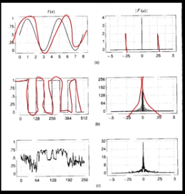

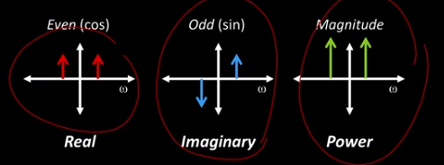

## Limitations

The integral $f(x) = \int_{-\infty}^{\infty} F(u) e^{i 2 \pi u x} du$ exists if the function f is integrable:

$$\int_{-\infty}^{\infty} | f(x) | dx < \infty$$

If there is a bound of width T outside of which f is zero than obviously the integration can be done from the bounds $-\frac{T}{2}$ to $\frac{T}{2}$. This helps avoid the trap of infinites in discrete computation.

**‘But I thought we had infinite repeating series?’**

Now we’re talking about the Fourier *transform*. A Fourier series was all about repeating functions but the *transform* is all about integrable functions.

## Fourier Transform to Fourier Series

A discrete transform is necesary for computers to sidestep symbolic math.

**The discrete Fourier Transform**:

In this formula k is a discrete frequency and is sum over all multiple of $\pi$.

$$F(k) = \frac{1}{N} \sum_{x=0}^{n=N-1} f(x) e^{-i\frac{2 \pi k x}{N}}$$

Where x is discrete and goes from the start of the signal to the end (N-1) and k is the number of cycles per period of the signal which effectively equates to cycles per image.

Instead of thnking of frequency as wiggliness in time now think of the wiggliness over the length of the image. Think in terms of ‘Cycles per image’.

The range of k effectively maxes from -N/2 to N/2 because the highest unambigous frequency you can have in a discrete vector of length N is N/2.

## 2D

The concept extends fairly simply to two dimensions.

The *discrete* two dimensional Fourier Transform: $F(k_x,k_y)=\frac{1}{N} \sum_{x=0}^{x=N-1} \sum_{y=0}^{y=N-1} f(x,y) e^ \frac{-i 2 \pi (k_x x + k_y y)}{N}$.

The discrete transform works best when the origin of k is geometrically centered.

Remember above how a linear combination of horizontal and vertical bases could be combined? (remember the face of your forefathers!) What does that look like when we apply this to an image?

You can see from the images that you have points / peaks where the frequency is! What does the power spectra of the Fourier transform look like? There are peaks where the unique frequencies present are isolated.

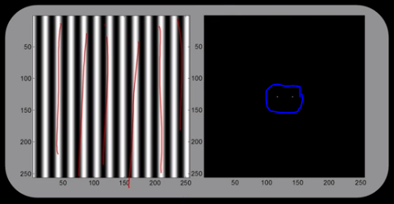

Vertical Lines

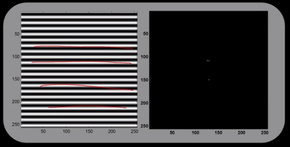

Horizontal Lines

### Linearity

Fourier transforms are linear operations made of sums and products! The Fourier transform of the sum is the sum of the Fourier transforms. This is depicted visually to the right

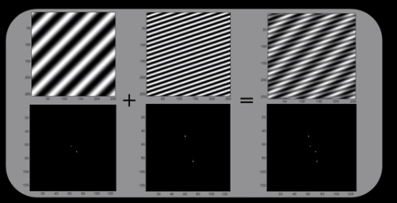

Linear Sum

## Examples

### Spectra of real images:

Suppose we wanted to remove high frequency content? You can take an image, find the power spectra, remove outliers, and reconstruct the image. This introduces ugly lines, called ringing. The original high frequencies were necessary to smooth the image.

[figure not shown]

There is also example of removing the stuff from the middle (far right image, this is called coring) and what’s left is basically an edge image; the high frequency components are basically the edges!

What about a sharpening filter? Here we’ve normalized the frequency spectra to accentuate the high frequencies and produced a sharper image.

[figure not shown]

## Man Made Scene

[^1]: https://en.wikipedia.org/wiki/Basis_(linear_algebra)
[^2]: https://en.wikipedia.org/wiki/Fourier_series
[^3]: https://en.wikipedia.org/wiki/Even_and_odd_functions